# Final_Report_Part1

## 0. Introduction

> This project aims to analise the income difference between male and female and how did this income disparity varied depending on other factors. The dataset was meticulously gathered by questioning the same people on many different occasions across the span of thirty-three years. It was clear that there was income data from three separate years i.e. **1990, 2000, and 2012.** And the report will study datas in all three years. **Note:** In order to make the report more readable, unless necessary, you may not see the all the code in html files. Please refer to Rmd files for the code.

### Rename variables

In order to make the code more readable and descriptive, all the variables and factors used in the project are renamed before the analysis start.

Notice that it is only a preliminary data processing, more detailed data handeling process will be displayed in the **Methodology** part.

## 1. Data Summary

> This part selects a small part of variables considered to be significant variables associated with the income disparity by project team at first. However, some of them may not be further analysed in the following part due to insignificance or colinearity.

### Family Attitude towards Women’s Role

The respondents were asked the question “EMPLOYMENT OF WIVES LEADS TO JUVENILE DELINQUENCY?” about their family attitudes during the year 1979. This attitude was indicative of an ultra-conservative mindset and hence it was chosen as an indicator for gender income disparity. The below table shows the variation of income based on the answer to the question.

| Response | gender | Mean income | Standard deviation of income | Median income |
| --- | --- | --- | --- | --- |
| Strongly disagree | Female | 13383.123 | 12449.49 | 12000 |
| Strongly disagree | Male | 20810.365 | 17028.24 | 19000 |
| Disagree | Female | 11666.831 | 11768.82 | 10000 |
| Disagree | Male | 19738.702 | 15607.11 | 18000 |
| Agree | Female | 9678.576 | 10886.15 | 7500 |
| Agree | Male | 19471.919 | 15466.41 | 18000 |
| Strongly agree | Female | 7939.758 | 10005.30 | 4000 |
| Strongly agree | Male | 16400.770 | 13526.07 | 15000 |
| NA | Female | 9055.143 | 10067.65 | 5500 |
| NA | Male | 17010.544 | 14938.64 | 15000 |

Here’s a graph showing the male and female income gropued together based on the responses:

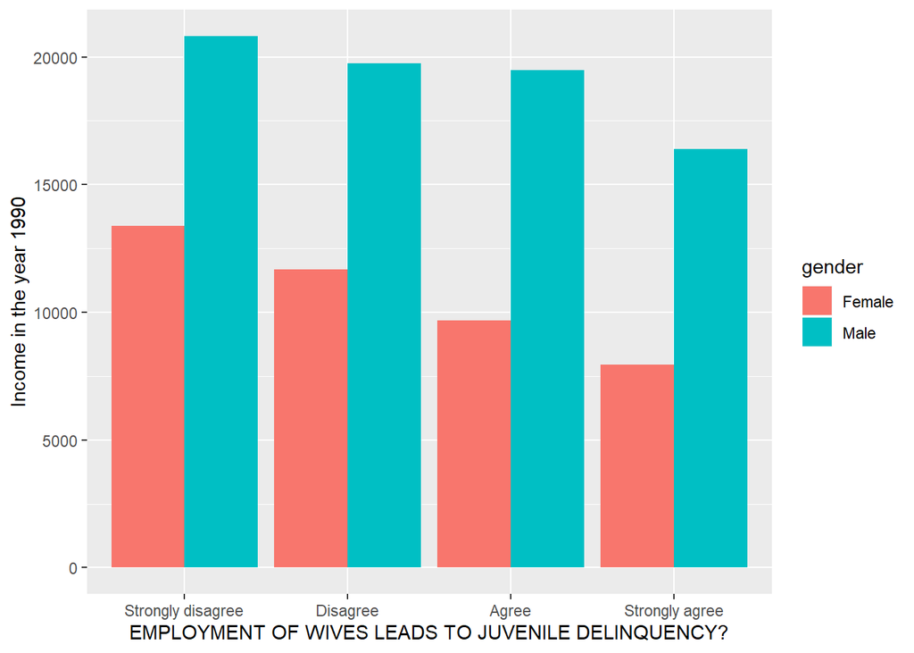

It is clear that the individuals who have this narrow-minded mentality have lower incomes irrespective of gender. But the disparity within the gender is unclear from this graph.

### Drug Use - Cocaine

In 1998, the respondents were questioned about the number of times they used cocain in their lifetime.

| gender | Number of times used cocaine (N) | Mean of N | Standard deviation of N | Median of N |
| --- | --- | --- | --- | --- |
| Female | 735 | 0.5193981 | 1.345321 | 0 |
| Male | 1196 | 0.9888559 | 1.809102 | 0 |

It is clear that the most common response is 0 times i.e. many people have never used cocaine in their life. But amogst those who have, men are more prone to use.

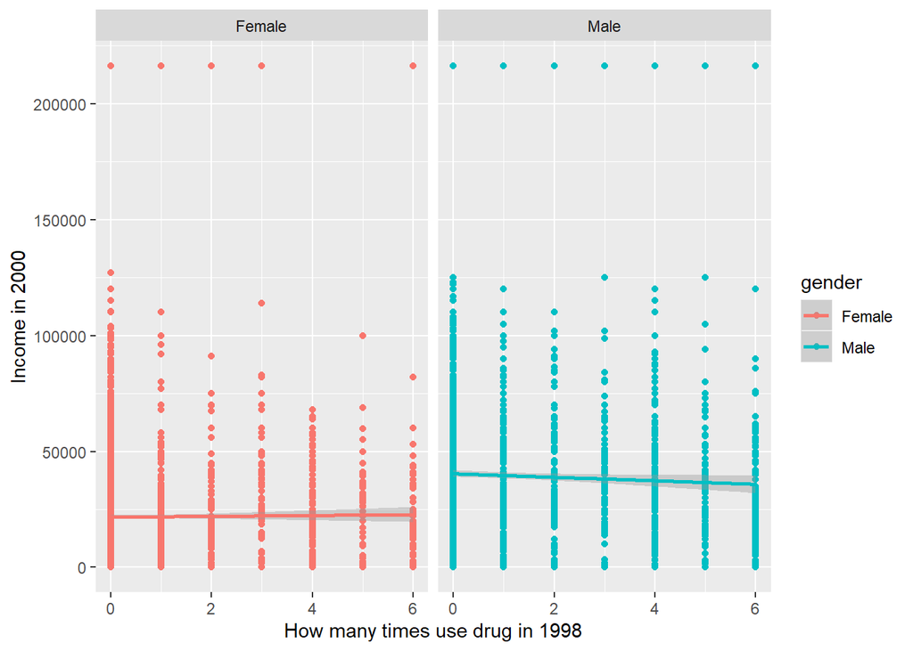

The factor might seem important in terms of affecting the income of an individual but it affects male income slightly and doesnt affect female income much. This could be because men are more prone to using cocaine in the first place.

### Number of children in the household

| gender | Total of number of children in the household (N) | Mean of N | Standard deviation of N | Median of N |
| --- | --- | --- | --- | --- |
| Female | 6283 | 1.3638242 | 1.250232 | 1 |
| Male | 6403 | 0.7922535 | 1.109833 | 0 |

From the table, it is clear that the average number of children in a female’s household is more than a male’s.

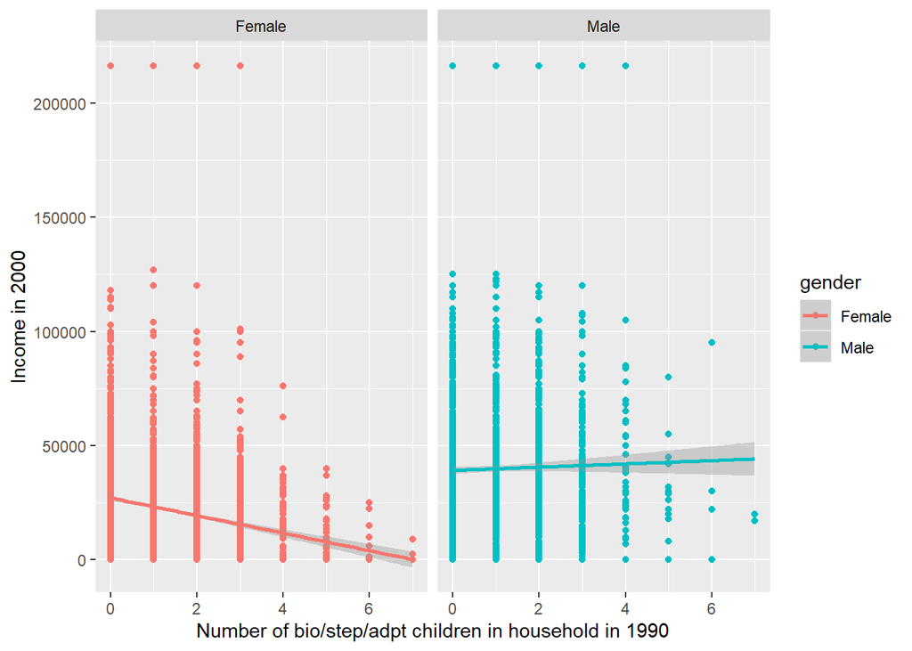

For women, the more children they have in the household, the lower income they earn, while there is no such a trend for men. In fact there is a slight increase in male income with the increase in the number of children in the household. Women are expected to take care of the household and increase in the number of kids affects their ability to earn tremendously.

### Age of youngest child

The age of the youngest child is a similar variable which seems to have some relevance in this regard.

| gender | Mean age of youngest child | Standard deviation of the age of youngest child | Median of the age of youngest child |
| --- | --- | --- | --- |
| Female | 4.270513 | 3.587755 | 3 |
| Male | 3.128181 | 3.211020 | 2 |

The youngest child’s age in female respondent’s household is on average greater than males respondent’s household. The above data can be used to correlated with the income as follows:

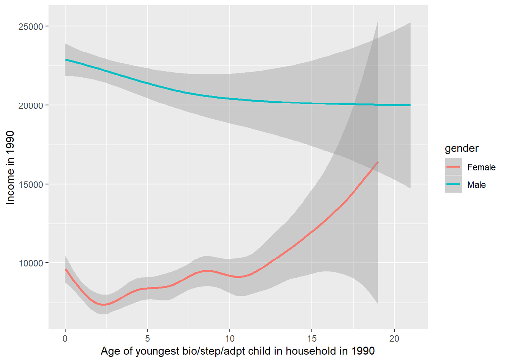

### Region

For 2012, Region from which the respondent hails from seems important Income Mapping. Here is a comparison of incomes based on region and gender:

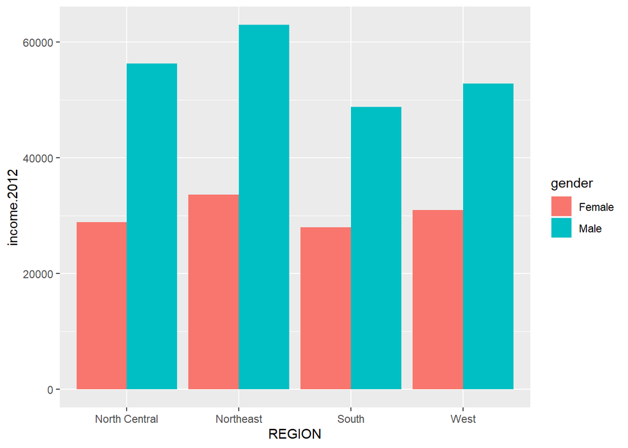

Clearly there is a gap between male and female incomes in each of the four regions. But this can be due to a variety of factors which we explore in our methodlogy and findings.

### Urban/Rural

For the 2012 income data, a similar trend can be seen in the urban and rural population.

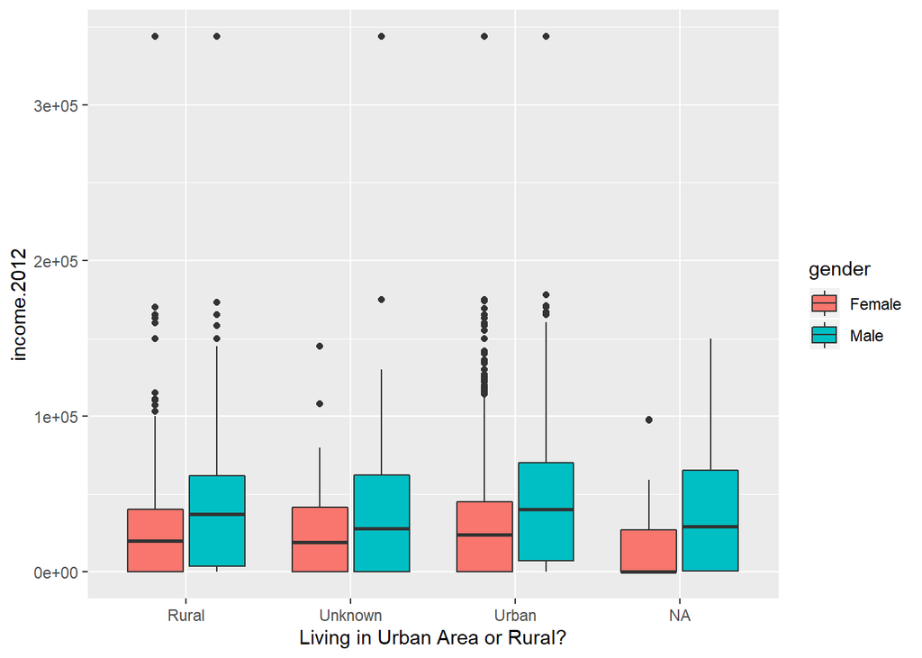

The male income is greater the femal income in almost all regions. A quartile of the population has zero income in all regions, except the male population in rural or urban areas.

### Race, Gender and Income

A distribution of income in 2012 by a combination of gender and race is given below.

| Race | gender | Mean income | Standard deviation of income | Median income |
| --- | --- | --- | --- | --- |
| Black | Female | 24095.83 | 26867.28 | 18000 |
| Black | Male | 32778.96 | 45932.29 | 22000 |
| Hispanic | Female | 27826.82 | 33723.72 | 20000 |
| Hispanic | Male | 46016.99 | 60222.21 | 35000 |
| Other | Female | 33570.33 | 39776.33 | 25000 |
| Other | Male | 69113.00 | 80097.79 | 50000 |

The income varies greately across the three races and two genders with the ‘Other’ race and ‘male’ gender having greater income than other races and gender.

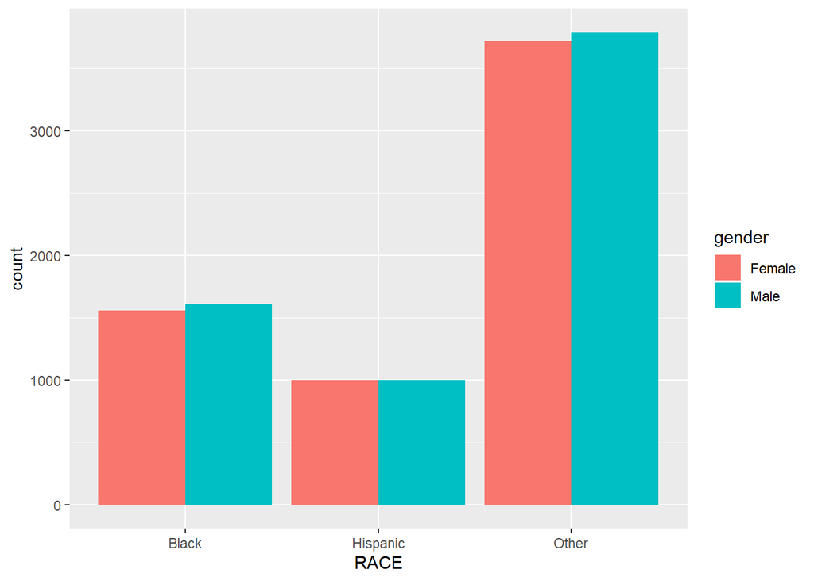

This difference in income in comparison comes with a large number of people in the ‘Other’ race which makes this difference even more significant.

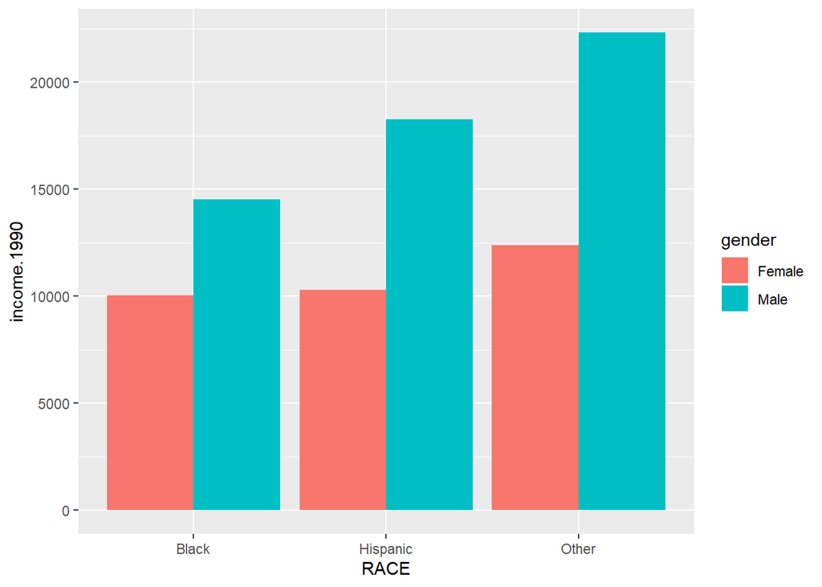

From a combined income comparison plot the income disparity is clear and obvious. But we need to explore the other data variables to get a fair assessment of gender bias in terms of income for male and female respondents of the survey.